# Fibonacci numbers and the Golden ratio

Jacob L. Fine

June 13th, 2024

The Fibonacci sequence is a sequence of numbers such that each term is the sum of the two previous terms.

It can be shown that the ratio between the nth and n-1th term approaches a constant, known as the Golden ratio ($\phi$), which is exactly equal to $\phi = \frac{1+\sqrt{5}}2$. We will derive this from the definition of the Fibonacci sequence and then compute it empircally.

We start with the definition of the Fibonacci sequence, where the $n$th term, $F_n$ is the sum of the previous two terms, so

$$F_n = F_{n-1}+F_{n-2}$$

At arbitarily large values of n, the ratio between a given pair of terms and the next pair of terms will equal the golden ratio, so

$$\phi
= \frac{F_n}{F_{n-1}}=\frac{F_{n-1}}{F_{n-2}}$$
We just substitute $F_n = F_{n-1}+F_{n-2}$ to obtain

$$\implies \frac{F_{n-1}+F_{n-2}
}{F_{n-1}}=\frac{F_{n-1}}{F_{n-2}}$$

$$\implies 1+
\frac{F_{n-2}}{F_{n-1}}-\frac{F_{n-1}}{F_{n-2}}=0$$
Now, we use that $\phi = \frac{F_{n-1}}{F_{n-2}}$ to rewrite the above as
$$\implies 1+
\frac{1}{\phi}-\phi=0$$
We just multiply through by $\phi$ to make the equation solvable using the quadratic formula:

$$\implies \phi + 1-\phi^2=0$$
$$\implies \phi^2 - \phi - 1=0$$
Therefore, since $\phi$ must be positive, we have that

$$\phi = \frac{1 + \sqrt{5}}{2}$$
We will now estimate this numerically using R, and compare our computations to the true value.

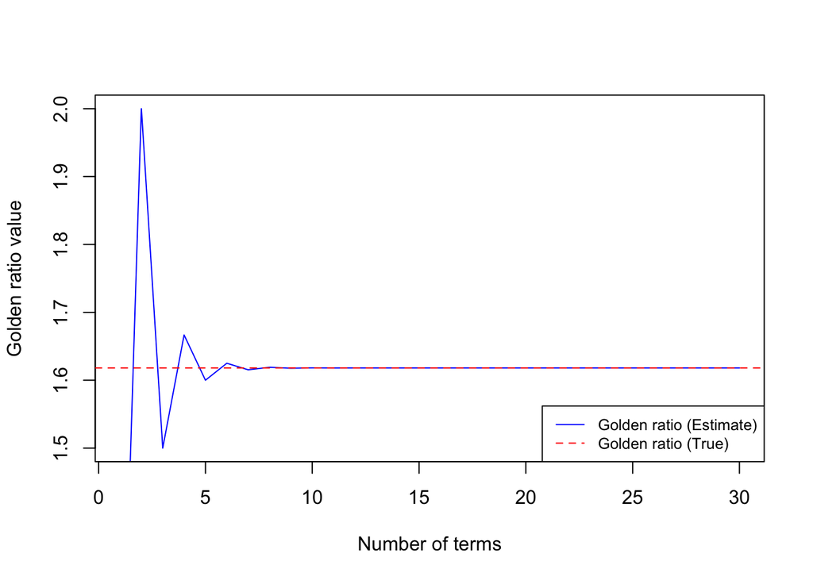

```r
# A function that computes the golden_ratio after n iterations
compute_golden_ratio <- function(n) {
  golden_ratio <- numeric(n)
  # initializes the golden_ratio as 1
  golden_ratio[1] <- 1
  # goes up until n, and computes the golden_ratio estimate as the ratio between the current term and the previous term
  for (i in 2:n) {
    golden_ratio[i] <- 1 + 1 / golden_ratio[i - 1]
  }
  # returns the golden ratio
  return(golden_ratio)
}

# calculates the golden_ratio after 20 terms
n <- 30
golden_ratio_seq <- compute_golden_ratio(n)

# Plotting the computed golden ratio against the true golden ratio
true_golden_ratio <- (1 + sqrt(5)) / 2
plot(1:n, golden_ratio_seq, type = "l", col = "blue", ylim = c(1.5, 2),
     xlab = "Number of terms", ylab = "Golden ratio value")
abline(h = true_golden_ratio, col = "red", lty = 2)
legend("bottomright", legend = c("Golden ratio (Estimate)", "Golden ratio (True)"),
       col = c("blue", "red"), lty = c(1, 2), cex = 0.8)
```